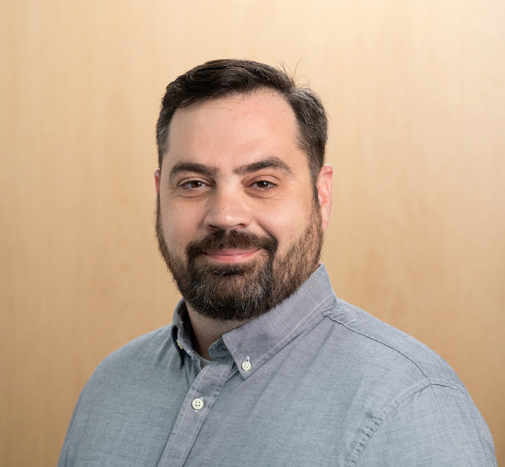

# Ian R. Turner

[figure not shown]

I am an Assistant Professor of [Political Science at Yale University](http://politicalscience.yale.edu/), where I’m also a Resident Fellow in the [Institution of Social and Policy Studies](http://isps.yale.edu/) and the [Center for the Study of American Politics](http://csap.yale.edu/), and a Faculty Affiliate of the [Leitner Program in International and Comparative Political Economy](http://leitner.yale.edu/). I have broad research interests in American political institutions, executive branch and bureaucratic politics, special interest politics, political economy, and applied game theory and formal modeling. My research has been published in leading academic journals such as the *American Political Science Review*, the *American Journal of Political Science*, the *Journal of Politics*, and the *Journal of Law, Economics, & Organization*. My teaching spans courses on American political institutions, bureaucratic politics, money in politics, game theory, and applied formal modeling. I was awarded the Poorvu Family Fund for Academic Innovation Award for excellence in teaching in 2024.

### Research

**Published & forthcoming**

- “[Democratic Accountability with Citizen Coproduction](https://osf.io/preprints/osf/gehwz_v1)” (with [Jie Ma](https://polisci.wustl.edu/people/jie-ma) and [Keith E. Schnakenberg](https://sites.wustl.edu/keschnak/)). Conditionally Accepted. *American Political Science Review*.  
  [[Ungated]](https://osf.io/preprints/osf/gehwz_v1)

  **Abstract**

  Many policies require citizens to actively and voluntarily participate in their implementation in order to produce successful outcomes, a situation referred to as *citizen coproduction*. Though citizen coproduction is necessary in many policy areas, it could create difficulties for democratic accountability because citizens and politicians share responsibility for policy failures and the attribution of blame may be difficult. We analyze the problem of democratic accountability with citizen coproduction in the context of a model in which politicians, who vary with respect to their competence at selecting policies, choose whether or not to implement policies whose success depends on the coproduction choices of citizens. For citizens, the problem is one of attribution: when citizen coproduction is low, it may be hard to select good incumbents because policy failures are frequent even in light of good policy choices. Furthermore, incumbent decisions anticipate these effects, which sometimes implies that incumbents are less likely to choose reforms when they are more likely to be successful.
- “[The Institutional Foundations of the Power to Persuade](http://doi.org/10.1111/ajps.12931)” (with [Carlo Prato](https://sites.google.com/site/carloprato1982/carlo-prato)). 2026. *American Journal of Political Science* 70(1): 120-135. [[Ungated]](https://osf.io/preprints/socarxiv/4w9af/)

  **Abstract**

  Formal Formal presidential authority does not always translate into real influence over policy outcomes: The bureaucratic actors that are responsible for policy implementation have considerable discretion. Presidents, however, have tools to influence their behavior. In this paper, we focus on presidential control of intra-executive *information flows*. We show how the President’s power to persuade depends on inter-branch relations and intra-branch institutions. We develop a theory in which the President can shape information available to bureaucratic subordinates via both overt, legitimate channels as well as covert, illegitimate interventions. We find that the President’s ability to persuade bureaucrats to pursue her preferred goals can be reinforced by higher bureaucratic independence or more aggressive external oversight. We also show how bureaucratic independence mediates how overseer motivations translate into oversight intensity. Our theory predicts that Congress’ investigative resources should target more independent agencies under divided government and less independent agencies under unified government.
- “[Presidential Leadership and Legislative Polarization](https://onlinelibrary.wiley.com/doi/10.1111/psq.70025)” (with [Benjamin S. Noble](https://benjaminnoble.org/)). 2026. *Presidential Studies Quarterly* 56(1). [[Ungated]](https://osf.io/preprints/socarxiv/sa9ke)

  **Abstract**

  When do presidents “go public” and how does that choice affect their prospects for legislative and electoral success? To answer these questions, we develop a two-period model of dynamic inter-branch policymaking in which two pivotal legislators must agree to change policy. Before lawmakers vote, the president has an opportunity to make an appeal in favor of his preferred policy, linking his approval rating and future electoral success to the legislative outcome. Doing so activates the parties’ electoral bases, creating additional strategic polarization beyond sincere preference disagreement between the two parties. Ultimately, we find that presidential appeals can create strategic polarization even in the absence of sincere preference polarization. We also uncover a new logic of defensive presidential appeals in which the president goes public to prevent policy defection from within his own party. This model helps disentangle the influence of party and preference polarization on legislative outcomes while generating new insights about when and why presidents go public.
- “[Dark Money and Politician Learning](https://www.journals.uchicago.edu/doi/10.1086/734548)” (with [Keith E. Schnakenberg](https://sites.wustl.edu/keschnak/)). 2026. *Journal of Politics* 88(1): 177-191. [[Ungated]](https://osf.io/preprints/socarxiv/3bzex/)

  **Abstract**

  We study the consequences of campaign finance disclosure laws in a model of informative campaign finance. Campaign spending can affect electoral outcomes and also signal policy information to politicians. Under mandatory disclosure donors may engage in spending that runs counter to their electoral interests in order to signal good news regarding their preferred policy. When donors can use dark money the electoral price to influence policy increases to account for the possibility that donors use public spending to signal, but secretly offset the electoral costs with dark money. Our results suggest that spending will tend to increase for moderate candidates and decrease for extreme candidates when dark money is allowed. We also illustrate how different social pressures affect patterns of campaign spending.
- “[Formal Theories of Special Interest Influence](https://www.annualreviews.org/content/journals/10.1146/annurev-polisci-051921-102335)” (with [Keith E. Schnakenberg](https://sites.wustl.edu/keschnak/)). 2024. *Annual Review of Political Science* 27: 401-421. [[Ungated]](https://osf.io/preprints/socarxiv/47e26/)

  **Abstract**

  The impact of money on politics – whether through campaign finance, lobbying, or independent expenditure – raises key normative questions about democratic representation and accountability. In recent years there has been a deluge of new data allowing researchers to study money in politics from new and exciting perspectives. As a complement to this trend there has also been a resurgence of interest in developing formal models to provide new theoretical insights that can help us understand how, why, and when money affects politics and policy. We review several major themes in this literature, focusing specifically on exchange-based models, informational models, and subsidy-based models. We compare and contrast the key contributions, and limitations, of each approach for understanding the role of lobbying and campaign finance in politics. We also discuss future avenues for research that incorporate aspects of each approach, which, we believe, will introduce new theoretical insights for understanding the role of money in politics.
- “[Motivated Reasoning and Democratic Accountability](https://www.cambridge.org/core/journals/american-political-science-review/article/motivated-reasoning-and-democratic-accountability/A5FDC6F7175255BDE8AA6AC054CD9176)” (with [Andrew T. Little](https://anthlittle.github.io/) and [Keith E. Schnakenberg](https://sites.wustl.edu/keschnak/)).  
  2022. *American Political Science Review* 116(2): 751-767. [[Ungated]](https://osf.io/preprints/socarxiv/esfy6/)

  **Abstract**

  Does motivated reasoning harm democratic accountability? Substantial evidence from political behavior research indicates that voters have “directional motives” beyond accuracy, which is often taken as evidence that they are ill-equipped to hold politicians accountable. We develop a model of electoral accountability with voters as motivated reasoners. Directional motives have two effects: (1) *divergence* – voters with different preferences hold different beliefs, and (2) *desensitization* – the relationship between incumbent performance and voter beliefs is weakened. While motivated reasoning does harm accountability, this is generally driven by desensitized voters rather than polarized partisans with politically motivated divergent beliefs. We also analyze the relationship between government performance and vote shares, showing that while motivated reasoning always weakens this relationship we cannot infer that accountability is also harmed. Finally, we show that our model can be mapped to standard models in which voters are fully Bayesian but have different preferences or information.
- “[Reviewing Procedure vs. Judging Substance: How Increasing Bureaucratic Oversight Can Reduce Bureaucratic Accountability](https://www.nowpublishers.com/article/Details/PIP-0049).”  
  2022. *Journal of Political Institutions and Political Economy* 2(4): 569-596. [[Ungated]](https://osf.io/preprints/socarxiv/v6kzw/)

  **Abstract**

  How does the scope of review affect bureaucratic policymaking? To explore this question, I consider a policymaking environment in which an expert agency develops policy that is upheld or overturned by an overseer who may have different policy goals. The agency can affect the quality of implementation through effort investments in addition to choosing the substantive content of policy. Under procedural review the overseer only reviews the agency’s effort, which allows the agency to fully utilize its expertise. Substantive review also tasks the overseer with judging agencies’ substantive policy choices, which can lead the agency to disregard its superior information and obfuscate to avoid reversal. Depending on the policy environment, this dynamic can either benefit or harm the overseer. In some cases the overseer can be made better off by having less transparent review institutions; that is, institutions that direct the overseer to only review procedure and preclude judging substance.
- “[Helping Friends or Influencing Foes: Electoral and Policy Effects of Campaign Finance Contributions](https://onlinelibrary.wiley.com/doi/full/10.1111/ajps.12534)” (with [Keith E. Schnakenberg](https://sites.wustl.edu/keschnak/)).  
  2021. *American Journal of Political Science* 65(1): 88-100. [[Ungated]](https://osf.io/preprints/socarxiv/nphgu/)

  **Abstract**

  Campaign finance contributions may influence policy by affecting elections or influencing the choices of politicians once in office. To study the trade-offs between these two paths to influence, we use a game in which contributions may affect electoral outcomes and signal policy-relevant information to politicians. In the model, an interest group and two politicians each possess private information correlated with a policy-relevant state of the world. The interest group may allocate its budget to either a candidate who shares its preferences or a moderate candidate whose preferences may diverge from the group’s preferred policy. Contributions that increase the likelihood of the moderate being elected can signal good news about the interest group’s preferred policy and influence the moderate’s policy choice. However, when the electoral effect of contributions is too small to demand sufficiently high costs to deter imitation by groups with negative information, this informational effect breaks down.
- “[Ex Post Review and Expert Policymaking: When Does Oversight Reduce Accountability?](https://www.journals.uchicago.edu/doi/abs/10.1086/708913)” (with [John W. Patty](http://www.johnwpatty.net/)).  
  2021. *Journal of Politics* 83(1): 23-39. [[Ungated]](https://osf.io/preprints/socarxiv/ugsqc/)

  **Abstract**

  Ex post review is a common feature of policymaking institutions. We consider a simple environment in which an expert agent makes a policy recommendation, which can then be accepted or rejected by a principal whose policy goals differ from those of the agent. The theory offers testable predictions about policy recommendations and the principal’s acceptance or rejection of these recommendations. The theory suggests that behavior and institutional design incentives are sensitive to both actors’ preference alignment and the importance of and uncertainty inherent to the policy area in multiple ways, some expected and some less obvious. We characterize the types of situations in which ex post review creates incentives for the agent to make pathological policy choices. In these situations, ex post review can reduce the accountability of the agent to the wishes of the principal and ultimately create an incentive for the principal to forego review entirely.
- “[Policy Durability, Agency Capacity, and Executive Unilateralism](https://onlinelibrary.wiley.com/doi/full/10.1111/psq.12633).”  
  2020. *Presidential Studies Quarterly* 50(1): 40-62. [[Ungated]](https://osf.io/preprints/socarxiv/stnzf/)

  **Abstract**

  In this essay I argue that the need to motivate bureaucrats to invest in high quality policy implementation alters the appeal of executive unilateralism. If executive orders are less durable than legislation, then the bureaucracy will have weaker incentives to invest in policymaking. This affects presidents’ willingness to compromise and work with Congress to pass legislation, rather than pursue unilateral action. Unilateralism becomes less attractive as bureaucratic capacity increases and as the relative durability of executive orders decreases. I formalize this logic in a simple formal model and discuss fruitful extensions for future work.
- “[Signaling with Reform: How the Threat of Corruption Prevents Informed Policymaking](https://www.cambridge.org/core/journals/american-political-science-review/article/signaling-with-reform-how-the-threat-of-corruption-prevents-informed-policymaking/DF50871EC917E7D2FE89EDCA3DFEF861)” (with [Keith E. Schnakenberg](https://sites.wustl.edu/keschnak/)).  
  2019. *American Political Science Review* 113(3): 762-777. [[Ungated]](https://osf.io/preprints/socarxiv/jkvz6/)

  **Abstract**

  Lobbying is a potential source of corruption but is also a valuable source of information for policymakers. We analyze a game-theoretic model that shows how the threat of corruption affects the incentives of non-corrupt politicians to enlist the help of lobbyists to make more informed decisions. Politicians face a dilemma because voters cannot always tell whether a politician allows access to lobbyists in order to solicit corruption or to seek information. Thus, a non-corrupt politician may deny access to lobbyists to signal that she is non-corrupt even though doing so impedes her ability to make good policy. This signaling may decrease the welfare of the voters depending on the value of the lost policy information relative to the value of screening out corrupt politicians.
- “[Political Agency, Oversight, and Bias: The Instrumental Value of Politicized Policymaking](https://academic.oup.com/jleo/advance-article/doi/10.1093/jleo/ewz011/5530862?guestAccessKey=fa2f5fb7-1c21-4493-9d56-c7f599608b33).”  
  2019. *Journal of Law, Economics, & Organization* 35(3): 544-578. [[Ungated]](https://osf.io/preprints/socarxiv/ebp5m/)

  **Abstract**

  We develop a theory of policymaking between an agent and an overseer, with a principal whose welfare is affected by agent-overseer interactions. The agent can increase the quality of policy outcomes through costly capacity investments. Oversight and agent bias jointly determine optimal agent capacity investments. We show that when oversight improves agent investment incentives the principal always benefits from an agent with biases opposite the overseer. Competing agent-overseer biases translate into higher quality policy outcomes than the principal could induce were she monitoring the agent. Effective oversight is necessary for these incentive effects. The results imply that political principals ought to consider the nature of the broader policymaking environment when appointing agents to make policy on their behalf and when designing managerial strategies aimed at motivating agents.
- “[Legislative Capacity and Credit Risk](https://onlinelibrary.wiley.com/doi/abs/10.1111/ajps.12368)” (with [David Fortunato](http://davidfortunato.com/)).  
  2018. *American Journal of Political Science* 62(3): 623-636. [[Ungated]](https://osf.io/preprints/socarxiv/4cdu8/)  
  [[Dataverse]](https://dataverse.harvard.edu/dataset.xhtml?persistentId=doi:10.7910/DVN/WYA1S2)

  **Abstract**

  Legislatures differ in their institutional capacity to draft and enact policy. While strong legislatures can increase the congruence of policy outcomes to the electorate’s preferences, they can also inject uncertainty into markets with their ability to alter the political economic landscape. We argue that this uncertainty will manifest in a state’s ability to borrow and hypothesize a negative relationship between legislative capacity and credit-worthiness. Using ratings of general obligation bonds issued by the American states over nearly two decades and data on the institutional capacity of state legislative assemblies, we find support for the claim that having a legislature that is better equipped to affect policy change increases credit risk evaluations. The results we present broaden our understanding of the importance of legislative institutions, the determinants of credit risk, and the economic implications of democratic responsiveness.
- “[Allies or Commitment Devices? A Model of Appointments to the Federal Reserve](http://onlinelibrary.wiley.com/doi/10.1111/ecpo.12089/full)” (with [Keith E. Schnakenberg](https://sites.wustl.edu/keschnak/) and [Alicia Uribe-McGuire](http://aliciauribemcguire.com/)).  
  2017. *Economics & Politics* 29(2): 118-132. [[Ungated]](https://osf.io/preprints/socarxiv/b5zts)

  **Abstract**

  We present a model of executive-legislative bargaining over appointments to independent central banks in the face of an uncertain economy with strategic economic actors. The model highlights the contrast between two idealized views of Federal Reserve appointments. In one view, all politicians prefer to appoint conservatively biased central bankers to overcome credible commitment problems that arise in monetary policy. In the other, politicians prefer to appoint allies, and appointments are well described by the spatial model used to describe appointments to other agencies. Both ideals are limiting cases of our model, which depend on the level of economic uncertainty. When economic uncertainty is extremely low, politicians prefer very conservative appointments. When economic uncertainty increases, politicians’ prefer central bank appointees closer to their own ideal points. In the typical case, the results are somewhere in between: equilibrium appointments move in the direction of politician’s preferences but with a moderate conservative bias.
- “[Working Smart *and* Hard? Agency Effort, Judicial Review, and Policy Precision](http://journals.sagepub.com/doi/full/10.1177/0951629816630430).”  
  2017. *Journal of Theoretical Politics* 29(1): 69-96. [[Ungated]](https://www.dropbox.com/s/91m86f0qr4s4sb7/turner-jtp-smart-and-hard.pdf?raw=1)

  **Abstract**

  The lion’s share of policy in the United States is made by administrative agencies. Agencies not only make policy *choices*, they must also *implement* policy effectively. Oversight institutions play an integral role in the policymaking process by monitoring, through review of agency policy actions, both policymaking tasks. Through analysis of a formal model I develop a theory of policymaking between agencies and courts and show that review can impact agency effort choices even when bureaucratic subversion is not a concern. At times the court has no impact on this effort and the agency is unconstrained. However, when the agency’s effort dictates whether or not the court defers to the agency’s actions judicial review does affect effort decisions. In this setting, review can either strengthen or, counter-intuitively, weaken agency effort incentives. Implications for executive and congressional oversight are discussed in light of these results.

**Selected work in progress**

- *Accountable Administration: Separation of Powers and Political Control of the Administrative State* (book project)  
  [[Outline]](https://www.dropbox.com/scl/fi/udaw8mux3qu0pr8l0xqm6/book_outline_2025_ONLINE.pdf?rlkey=hwl03gsf2jgbb9s7g9784bjf7&raw=1)

  **Abstract**

  The scope and complexity of government work has grown exponentially over the 20th Century and into the 21st Century. In response, Congress has long delegated agencies policymaking authority to handle increasingly complex policy domains. At the same time, political polarization has reached record levels, rendering Congress seemingly unable to legislate effectively. This has led to increased efforts by administrative agencies to stretch their existing authority to its fullest. In response, all three branches have expressed concerns about how agencies might use this authority. Former President Donald Trump spent much of his time in office railing against the ‘deep state’ and promising to deconstruct the administrative state, culminating in the imposition of Schedule F: an executive order creating a new employment category that would strip thousands of government workers of civil service protections. Congress resurrected the long dormant Congressional Review Act (CRA) to overturn Obama-era regulations and has long had internal conversations about how the capacity for administrative oversight could be strengthened to rein in the bureaucracy. The Supreme Court has issued transformational decisions—redefining long-standing practices of judicial deference (Loper Bright (2024)), severely limiting congressional delegation (e.g., West Virginia v. EPA (2022), Biden v. Nebraska (2023)), and calling into question the constitutionality of agency independence (Seila Law (2020))—which represent a continued trend of judicial self-empowerment and a fundamental reconstitution of how the other branches can engage in political control of the administrative state. Given the importance and stakes for the American people, it is crucial we understand the dynamics of these political struggles for control of the administrative state. *Accountable Administration* develops a theoretical framework, supported by cases studies and historical narratives, that clearly and systematically indicates how characteristics of the policy environment, agencies themselves, and bureaucratic control institutions (e.g., judicial review, delegation, and personnel management) help us evaluate and understand bureaucratic decision-making and predict the effect of these ongoing developments in American politics seeking to rein in the administrative state. The book provides a distinctly political-institutional logic for how, when, and why strengthening efforts to control the bureaucracy can actually reduce bureaucratic accountability, which complicates the standard premise that political control is necessary for accountable administration.
- “[Dark Money and Voter Learning](https://osf.io/preprints/socarxiv/r562d/)” (with [Keith E. Schnakenberg](https://sites.wustl.edu/keschnak/) and [Collin Schumock](https://politicalscience.yale.edu/people/collin-schumock)). **R&R.**

  **Abstract**

  We provide a model of dark money in elections. An ideologically extreme donor with private information about candidate ideology and quality can advertise on behalf of a candidate. Advertising reveals information about candidate quality to voters, who can learn from either donor-funded or neutral advertising. Voters update negatively about candidate ideology when ads are known to be donor-funded. Dark money suppresses source information and allows donors to advertise candidate quality while simultaneously concealing the ideological motivations behind ad funding. However, dark money leads voters to become skeptical of all advertising, which can disadvantage donors.
- “[Strange Bedfellows: How the Need for Good Governance Shapes Budgetary Control of Bureaucracy](https://osf.io/preprints/osf/pnx2u)” (with [John W. Patty](http://www.johnwpatty.net/)). **R&R.**

  **Abstract**

  Legislators can benefit from delegation to executive agencies, but they have limited tools to hold these agencies accountable. One of the most important tools is the agency’s appropriations. We present a theory that incorporates (1) heterogeneous legislator preferences over bureaucratic activity, (2) legislative budgetary control, and (3) endogenous bureaucratic policy discretion to understand legislative incentives when appropriating funds to bureaucratic agencies. Our theory provides several insights: first, legislators’ induced preferences over budgets are partially determined by their policy preferences; second, in some cases legislators who are “opposed” to the direction that the agency will take policy nevertheless support increased funding for that agency; finally, ``strange bedfellows” coalitions emerge in which legislators with competing policy preferences may nonetheless agree on their most-desired budget level for the agency.
- “[Managing Government Hierarchy: Electoral Turnover and Intra-Governmental Cooperation](https://osf.io/preprints/socarxiv/xuvjc)” (with [Christopher M. Li](https://sites.google.com/a/u.northwestern.edu/christopher-li/home-1) and [Greg Sasso](https://gregsasso.me/)). **R&R.**

  **Abstract**

  Theories of political accountability often consider voter-politician interactions in isolation from politician-bureaucrat interactions. We study a model of electoral accountability with a governing hierarchy: voter-politician-bureaucrat. The politician and bureaucrat both produce government output valued by the voter. The voter controls the politician via election and the politician provides incentives to bureaucrats. We show that when times are conducive to high quality governance—budgets are large and players are farsighted—incorporating the politician-bureaucrat relationship leads to weaker accountability standards. However, when times are tough and budgets are small or players are myopic voters may benefit from adopting more demanding standards.
- “[Hierarchical Control](https://osf.io/preprints/socarxiv/5gt8y/)” (with [Christopher M. Li](https://sites.google.com/a/u.northwestern.edu/christopher-li/home-1) and [Greg Sasso](https://gregsasso.me/)).

  **Abstract**

  The problem of enforcing democratic accountability typically focuses on the control of elected politicians. While a key contributor to government performance, the bureaucracy is largely insulated from direct electoral pressure but still subject to indirect control by politicians. Could elections be used to motivate both politicians directly and, indirectly, bureaucrats? We explore the nature of hierarchical control in a model with a representative voter, elected politicians, and unelected bureaucrats. The politician and bureaucrat exert effort to jointly produce government output valued by the voter. The voter controls the politician’s tenure in office through elections, and the politician manages the bureaucrat through relational incentives. We illustrate how voter welfare and the overall quality of governance responds to changes in the policy environment, e.g., office rents, effort costs, and players’ discount factors. In doing so, we provide a flexible framework to calibrate expectations for government performance, electoral accountability, and voter welfare across political-economic contexts.
- “Bargaining in the Shadow of Bureaucracy”

  **Abstract**

  Across the world, the most common contact citizens have with the state is through their interactions with bureaucrats. Yet, compared to the study of relationships between bureaucrats and other elite political actors (e.g., legislators, executives, etc.), the crucial relationship between street-level or frontline bureaucrats and citizens remains understudied and our knowledge falls short of reflecting its importance. A burgeoning literature on *bureaucratic embeddedness*, adapting the concept of social embeddedness from sociology to political settings, has begun to fill this important gap in knowledge. In this article, I develop a conceptual framework that incorporates myriad ways bureaucratic embeddedness has been used to study how the different constellations of political-economic environments, goals of central state authority, bureaucrats, and citizens, and the mechanisms of embeddedness interact to determine the quality of state governance. I highlight how the overall context of citizen-state interactions dictate the quality of those interactions, and how bureaucratic embeddedness, in particular, can be either positive or negative from the perspective of how agents of the state intervene in the everyday lives of citizens. Ultimately, the analysis provides an array of substantive implications that vary across empirical contexts and organizes existing empirical insights regarding how the state uses management of its agents to provide for and control local populations while providing comparative predictions to guide future empirical research.
- “Identity, Citizen Expectations, and Representative Bureaucracy: Theory and Experimental Evidence” (with [Jen Wu](https://www.jen-wu.com/)).

  **Project Description**

  How do the identities of bureaucratic representatives affect citizens’ perceptions of the representative and the agency they represent? Public good and service provision by bureaucratic agencies are processes in which citizens interact with the government, often in a context where the presence of government is less visible compared to settings such as campaigns and elections. While much has been written about representative bureaucracy, i.e., how sharing group identity affects the quality of service or good (Mosher 1968, Selden 1997, Meier 2019), the mechanisms undergirding the connections between shared identity and bureaucrat behavior remain vague, particularly with regards to citizens’ perspective. From the agency’s perspective, there may be reasons to send an agent that is embedded or not embedded depending on their goals, ranging from minimizing agent shirking (Hassan 2020) to optimizing the quality of service or goods provision (Grossman and Slough 2022; Xu 2021; Butler and Broockman 2011; Tsai 2007; Evans 1995). Notably, work on bureaucratic embeddedness has been limited in the American context (Pepinsky 2017; Brierley et al. 2023). Moreover, research relevant to the question of whether agencies should rely on embedded bureaucrats overlooks the citizen’s perspective in their interactions with the bureaucrat. To this end, our project aims to answer the opening question as a means to 1) examine the citizen-agency interaction in the American context and 2) identify specific mechanisms that support the generally positive relationship between shared identity and quality of provision. First, we ask whether there are benefits to the agency by having embedded bureaucrats based on citizen perceptions. Do individuals perceive an embedded bureaucrat to be more likely to behave in favor of their community or group and does that also improve attitudes towards the agency? Second, we ask whether citizen perceptions of embedded bureaucrats are driven by three particularly mechanisms that potentially explain why embedded status may be salient in agent behavior. We characterize the mechanisms into the following three categories: 1) informational (whether an agent has prior knowledge about the community based on being from the community), 2) valence (whether an agent is more likely in the community’s interests when they are or are not from the community), and 3) social pressure (whether the agent faces pressure from their community to serve their interests at the cost of the agency’s interests).

### Teaching

**APSA Formal Theory Section Teaching Resources**

- [Link to Google Drive folder](https://drive.google.com/drive/folders/1oBpHY8agGONQ33kI_TeC5CVg6qHC-RE7)

**Yale University**

- *Recipient*: 2024 Poorvu Family Fund for Academic Innovation Award for Excellence in Teaching
- Advanced Models of Political Economy | [Syllabus](https://www.dropbox.com/scl/fi/231xt3iongso8z1rkl65u/plsc520-Spring24.pdf?rlkey=lppnpozplykyonzr980pm0p56&raw=1)
- Introduction to Formal Political Economy | [Syllabus](https://www.dropbox.com/scl/fi/urcf6jvbpjhoqb04o0yd3/519-syllabus-2025.pdf?rlkey=vk2eiwijll15qonjfabqh73db&raw=1)
- Game Theory & Political Science | [Syllabus](https://www.dropbox.com/s/xlohsydqjytp66u/ug-gt-2021.pdf?raw=1)
- Democracy & Bureaucracy | [Syllabus](https://www.dropbox.com/s/k0qseoj08v6cmf9/bureaucracy-syllabus-spring21.pdf?raw=1)
- Interest Groups, Money, and Influence in American Politics | [Syllabus](https://www.dropbox.com/s/x2zi9jc5qckdzg6/money-politics-syllabus-fall2017.pdf?raw=1)
- Formal Models of American Politics | [Syllabus](https://www.dropbox.com/s/l7z04o7egew4slj/formal-american-2020.pdf?raw=1)
- Formal Models of Accountability | [Syllabus](https://www.dropbox.com/s/rewzke3re2twem8/accountability-representation-spring18-syl.pdf?raw=1)

**Texas A&M University**

- Game Theoretic Methods in Political Science | [Syllabus](https://www.dropbox.com/s/j4610u9jzxgfqou/POLS308-500-syllabus-final-2016.pdf?raw=1)
- Formal Models of Bureaucracy | [Syllabus](https://www.dropbox.com/s/t2k7hj7e8msq1ls/formal-bureaucracy-grad.pdf?raw=1)
- Political Institutions | [Syllabus](https://www.dropbox.com/s/u5n49zya5s5gpeh/Political-Institutions-Syllabus-Summer-2016.pdf?raw=1)

#### Office

A105, ISPS, 77 Prospect Street

#### Contact information

Yale University  
Department of Political Science  
P.O. Box 208301  
New Haven, CT 06520-8301